# LR2 Problem

Riyaz Panjwani

September 26, 2016

## Phishing Site Detection Using ML Algorithm

In todays world where almost all user data is online, phishing has become a major menace. We want to classify websites as phishing websites based on some attributes. Numbers against the attributes show the possible categories for that attribute. The descriptions for the features have been given only to fulfill your curiosity.

## Approach To the Problem

The problem seems to be quite trivial use of classification algorithm. We can use any of the popular classifiaction algorithm like Neural Netwoks, Decision Tress, Boosting , SVM and others.

I have used Boosting because of increased accuracy however I have also used SVM and decision tree.The later were discarded due to not lower efficientcy being 91.2% and 90.99% respectivley.

## Getting the Data

In order to reproduce the same results, you need a certain set of packages, as well as setting a pseudo random seed equal to the one I used. *Note*:To install, for instance, the caret package in R, run this command: install.packages(“caret”)

The following Libraries were used for this project, which you should install - if not done yet - and load on your working environment.

```r
library(ggplot2)
library(lattice)
library(caret)
library(car)
library(corrplot)
library(Rtsne)
library(xgboost)
library(stats)
library(knitr)
```

For fast and accurate training the model, I choose XGBoost, an implementation of tree-based extreme gradient boosting algorithm.

```r
train <- read.csv("C:\\Users\\Aryan\\AppData\\Local\\Temp\\RtmpCyK3CX\\data13a413a12886", header=FALSE)
test <- read.csv("C:\\Users\\Aryan\\AppData\\Local\\Temp\\RtmpCyK3CX\\data13a413fb684a", header=FALSE)

dim(train)
```

```
## [1] 9055   31
```

```r
dim(test)
```

```
## [1] 2000   30
```

```r
names(train)
```

```
##  [1] "V1"  "V2"  "V3"  "V4"  "V5"  "V6"  "V7"  "V8"  "V9"  "V10" "V11"
## [12] "V12" "V13" "V14" "V15" "V16" "V17" "V18" "V19" "V20" "V21" "V22"
## [23] "V23" "V24" "V25" "V26" "V27" "V28" "V29" "V30" "V31"
```

## Data Cleaning

The data appears to be clean with no *NA* Values.The values are either 0,1,-1 and the output being -1 – > False and 1 –> True

```r
out <- train[,31]
head(out)
```

```
## [1] -1  1  1  1 -1  1
```

```r
train$V31 <- factor(train$V31,
                    levels = c(-1,1),
                    labels = c("0", "1"))
```

The only major problem with the data is the output which is either -1 or 1. But XGBoost requies the output data to be [0,num_class) where num_class is the number of classification classes here being 2.

```r
train.org <- read.csv("C:\\Users\\Aryan\\AppData\\Local\\Temp\\RtmpCyK3CX\\data13a413a12886", header=FALSE)

out <- train[,31] == 1
levels(out)
```

```r
levels(out) <- 1 : length(levels(out))

train$V31 = NULL

cols.without.na <- colSums(is.na(test)) == 0
train <- train[,cols.without.na]
test <- test[,cols.without.na]
```

## Preprocessing

### Check for features’s varaiance

Based on the principal component analysis PCA, it is important that features have maximum variance for maximum uniqueness, so that each feature is as distant as possible (as orthogonal as possible) from the other features.

```r
zero.var = nearZeroVar(train, saveMetrics=TRUE)
zero.var
```

```
##     freqRatio percentUnique zeroVar   nzv
## V1   1.908770    0.02208724   FALSE FALSE
## V2   4.630353    0.03313087   FALSE FALSE
## V3   6.719523    0.02208724   FALSE FALSE
## V4   5.727340    0.02208724   FALSE FALSE
## V5   6.712947    0.02208724   FALSE FALSE
## V6   6.558431    0.02208724   FALSE FALSE
## V7   1.102769    0.03313087   FALSE FALSE
## V8   1.784732    0.03313087   FALSE FALSE
## V9   2.009305    0.02208724   FALSE FALSE
## V10  4.405970    0.02208724   FALSE FALSE
## V11  6.446546    0.02208724   FALSE FALSE
## V12  5.159864    0.02208724   FALSE FALSE
## V13  1.462605    0.02208724   FALSE FALSE
## V14  1.635584    0.03313087   FALSE FALSE
## V15  1.137407    0.03313087   FALSE FALSE
## V16  4.563036    0.03313087   FALSE FALSE
## V17  4.548407    0.02208724   FALSE FALSE
## V18  5.828808    0.02208724   FALSE FALSE
## V19  7.665072    0.02208724   FALSE FALSE
## V20  7.423256    0.02208724   FALSE FALSE
## V21 22.277635    0.02208724   FALSE  TRUE
## V22  4.162486    0.02208724   FALSE FALSE
## V23  9.909639    0.02208724   FALSE FALSE
## V24  1.118129    0.02208724   FALSE FALSE
## V25  2.251346    0.02208724   FALSE FALSE
## V26  2.174966    0.03313087   FALSE FALSE
## V27  2.891276    0.02208724   FALSE FALSE
## V28  6.096395    0.02208724   FALSE FALSE
## V29  1.436137    0.03313087   FALSE FALSE
## V30  6.158103    0.02208724   FALSE FALSE
```

## Plot of correlation Matrix

Plot a correlation matrix between features. A good set of features is when they are highly uncorrelated (orthogonal) each others. The plot below shows average of correlation is not too high, so I choose to not perform further PCA preprocessing.

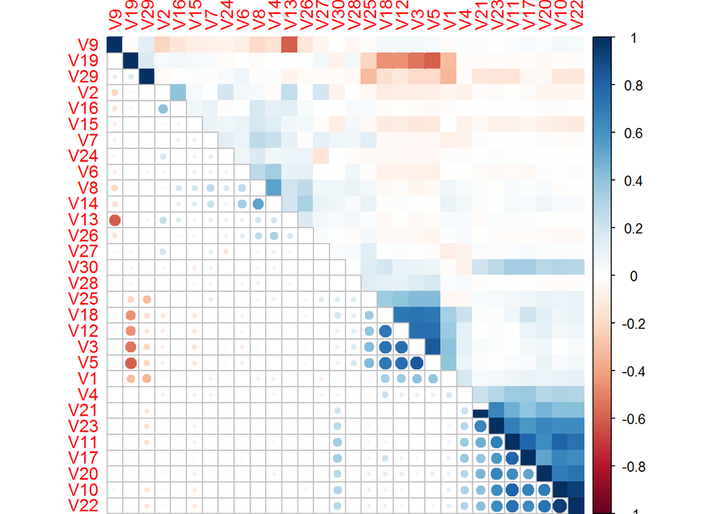

```r
corrplot.mixed(cor(train), lower="circle", upper="color",
               tl.pos="lt", diag="n", order="hclust", hclust.method="complete")
```

## Build Machine Learning Model

### XGBOOST Data

XGBoost supports only numeric matrix data. Converting all training, testing and outcome data to matrix.

```r
# convert data to matrix
train.matrix <- as.matrix(train)
mode(train.matrix) <- "numeric"
test.matrix <- as.matrix(test)
mode(test.matrix) <- "numeric"
# convert outcome from factor to numeric matrix
#   xgboost takes multi-labels in [0, numOfClass)
y <- as.matrix(as.integer(out))
```

### XGBOOST Parameters

Set XGBoost parameters for cross validation and training. Set a multiclass classification objective as the gradient boosting’s learning function. Set evaluation metric to merror, multiclass error rate

```r
param <- list("objective" = "multi:softprob",    # multiclass classification
              "num_class" = length(levels(out)),    # number of classes
              "eval_metric" = "merror",    # evaluation metric
              "nthread" = 8,   # number of threads to be used
              "max_depth" = 16,    # maximum depth of tree
              "eta" = 0.3,    # step size shrinkage
              "gamma" = 0,    # minimum loss reduction
              "subsample" = 1,    # part of data instances to grow tree
              "colsample_bytree" = 1,  # subsample ratio of columns when constructing each tree
              "min_child_weight" = 12  # minimum sum of instance weight needed in a child
)
```

### 4 Fold CV

```r
set.seed(1234)
# k-fold cross validation, with timing
nround.cv <- 50
system.time( bst.cv <- xgb.cv(param=param, data=train.matrix, label=y,
                              nfold=4, nrounds=nround.cv, prediction=TRUE, verbose=FALSE) )
```

```
##    user  system elapsed
##   16.69    2.19   11.11
```

The time elapsed is around 12 sec !! :)

```r
tail(bst.cv$dt)
```

```
##    train.merror.mean train.merror.std test.merror.mean test.merror.std
## 1:          0.020210         0.001319         0.037990        0.004005
## 2:          0.020247         0.001615         0.038212        0.003641
## 3:          0.019768         0.001560         0.037770        0.003439
## 4:          0.019695         0.001404         0.037880        0.003096
## 5:          0.019437         0.001295         0.037880        0.003301
## 6:          0.019363         0.001051         0.038432        0.003333
```

```r
min.merror.idx <- which.min(bst.cv$dt[, test.merror.mean])
min.merror.idx
```

```
## [1] 47
```

And the stats being

```r
bst.cv$dt[min.merror.idx,]
```

```
##    train.merror.mean train.merror.std test.merror.mean test.merror.std
## 1:          0.019768          0.00156          0.03777        0.003439
```

### Moment Of Silence

Lets finally plot the **confusion matrix** and plot the relevant stats to make the final estimate about the model

```r
#predict

pred.cv <- matrix(bst.cv$pred, nrow=length(bst.cv$pred)/length(levels(out)), ncol=length(levels(out)))
pred.cv <- max.col(pred.cv, "last")

#Confusion Matrix
confusionMatrix(factor(y+1), factor(pred.cv))
```

```
## Confusion Matrix and Statistics
##
##           Reference
## Prediction    1    2
##          1 3815  196
##          2  152 4892
##
##                Accuracy : 0.9616
##                  95% CI : (0.9574, 0.9654)
##     No Information Rate : 0.5619
##     P-Value [Acc > NIR] : < 2e-16
##
##                   Kappa : 0.922
##  Mcnemar's Test P-Value : 0.02116
##
##             Sensitivity : 0.9617
##             Specificity : 0.9615
##          Pos Pred Value : 0.9511
##          Neg Pred Value : 0.9699
##              Prevalence : 0.4381
##          Detection Rate : 0.4213
##    Detection Prevalence : 0.4430
##       Balanced Accuracy : 0.9616
##
##        'Positive' Class : 1
##
```

I can also compare the data

```r
#this contains 1 and 2's where 1 -->FALSE and 2 --> TRUE
#Since I want to compare the data on equal ground lets convert the data
train$V31 <- pred.cv
train$V31[train$V31 == 1] <- -1
train$V31[train$V31 == 2] <- 1

#library(compare)
#comparison <- compare(train$V31,train.org$V31,allowAll=TRUE)
#comparison$tM
```

This can be further explored if we know the places number of mistmatch which is another way of computing the same thing done by confusion matrix

```r
mis <- train$V31 == train.org$V31
#Wrongly Predicted Value
sum(mis == FALSE)
```

```
## [1] 348
```

```r
#Correctly Predicted Value
sum(mis == TRUE )
```

```
## [1] 8707
```

**Clearly the accuracy being 96.2% :)**

## Predcit the Test Data

```r
system.time( bst <- xgboost(param=param, data=train.matrix, label=y,
                           nrounds=min.merror.idx, verbose=0) )
```

```
##    user  system elapsed
##    6.61    0.52    5.61
```

```r
pred <- predict(bst, test.matrix)
head(pred,15)
```

```
##  [1] 0.0252717081 0.9747282863 0.2331943363 0.7668057084 0.1863012463
##  [6] 0.8136987090 0.9824017882 0.0175982397 0.9992477894 0.0007522993
## [11] 0.0004522691 0.9995476604 0.0008266514 0.9991733432 0.7325651646
```

### Post processing

Decode the output

```r
pred <- matrix(pred, nrow=2, ncol=length(pred)/2)
pred <- t(pred)
pred <- max.col(pred, "last")
pred.ans <- toupper(letters[pred])
head(pred.ans,5)
```

```
## [1] "B" "B" "B" "A" "A"
```

Now this is converted to normal form as

```r
pred.ans[pred.ans == "A"] <- -1
pred.ans[pred.ans == "B"] <-  1
head(pred.ans,5)
```

```
## [1] "1"  "1"  "1"  "-1" "-1"
```

### Feature Importance Plot

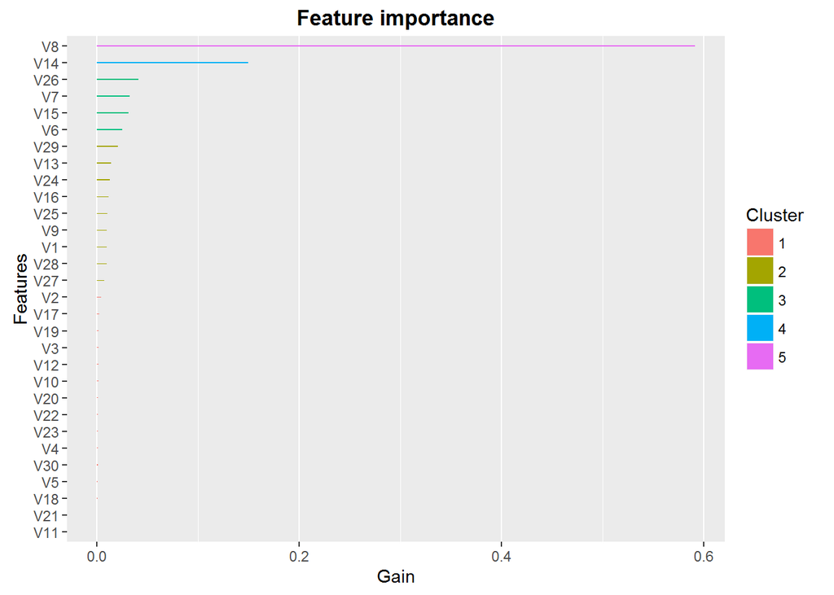

```r
# get the trained model
model <- xgb.dump(bst, with.stats=TRUE)
# get the feature real names
names <- dimnames(train.matrix)[[2]]
# compute feature importance matrix
importance_matrix <- xgb.importance(names, model=bst)

# plot
gp <- xgb.plot.importance(importance_matrix)
print(gp)
```